# Лабораторная работа №1 — Маркин Н. А.

Национальный исследовательский ядерный университет «МИФИ»

Дисциплина «Статистические исследования»

ЛАБОРАТОРНАЯ РАБОТА № 1

«Обработка анкет и описательная статистика в R: инфляционные ожидания и потребительские настроения»

Маркин Никита Алексеевич  
Группа Б24-902 · Вариант 95

Москва · 2026

# 1. Цель и проверка данных

Цель — обработать анкеты в R, рассчитать инфляционные медианы, доходы и потребительские индексы, сопоставить учебный сентябрь с опубликованным августом 2026 года.

Исходник: Маркин.Никита.Алексеевич_Б24-902_Вар95.xlsx; 2000 анкет, 21 столбец. Нет исходной категории дохода на человека; для групповых сравнений использованы пять квантильных групп расчетного дохода. Исходный XLSX не изменялся. Результаты проверок и пригодность показателей — в таблицах 1–2.

Таблица 1. Проверка структуры и значений

| Проверка | Число |
| --- | --- |
| Отсутствующие столбцы (единица — столбцы) | 1 |
| Отсутствующая характеристика дохода (затронуто анкет) | 2000 |
| Пустой ID | 0 |
| Строки с повторяющимся непустым ID | 0 |
| Недопустимая категория хотя бы в одном поле (строки) | 0 |
| Q12: пропуск, нечисловое, нецелое или неположительное | 0 |
| Q4 пусто, хотя поле требуется | 0 |
| Q4 заполнено, хотя поле не задавалось | 0 |
| Q6 пусто, хотя поле требуется | 0 |
| Q6 заполнено, хотя поле не задавалось | 0 |
| Тип предприятия работодателя пусто, хотя поле требуется | 0 |
| Тип предприятия работодателя заполнено, хотя поле не задавалось | 0 |

Таблица 2. Пригодные ответы N, технические и структурные пропуски

| Показатель | N | Тех. | Стр. | Недоп. |
| --- | --- | --- | --- | --- |
| Пол | 2000 | 0 | 0 | 0 |
| Возраст | 2000 | 0 | 0 | 0 |
| Образование | 2000 | 0 | 0 | 0 |
| Род занятий | 2000 | 0 | 0 | 0 |
| Тип предприятия работодателя | 1161 | 0 | 0 | 0 |
| Тип расселения | 2000 | 0 | 0 | 0 |
| Самооценка материального положения семьи | 2000 | 0 | 0 | 0 |
| Q1 | 2000 | 0 | 0 | 0 |
| Q2 | 2000 | 0 | 0 | 0 |
| Q3 | 2000 | 0 | 0 | 0 |
| Q4 | 1862 | 0 | 138 | 0 |
| Q5 | 2000 | 0 | 0 | 0 |
| Q6 | 1697 | 0 | 303 | 0 |
| Q7 | 2000 | 0 | 0 | 0 |
| Q8 | 2000 | 0 | 0 | 0 |
| Q9 | 2000 | 0 | 0 | 0 |
| Q10 | 2000 | 0 | 0 | 0 |
| Q11 | 2000 | 0 | 0 | 0 |
| Q13 | 2000 | 0 | 0 | 0 |
| Q12 | 2000 | — | — | — |
| infl_obs | 1445 | — | — | — |
| infl_exp | 1313 | — | — | — |
| Доход на человека | 1613 | — | — | — |

В расчетах испорченное поле не исключает анкету целиком. «Затрудняюсь» — допустимый ответ; пустота незаданного вопроса — структурный пропуск.

# 2. Частоты и доли ответов

$$p_j=\frac{n_j}{N}\cdot100\%.$$

Для вопросов всем N — число допустимых ответов; для Q4/Q6 — число респондентов, которым вопрос задавался. Технические пропуски показаны отдельно. Все допустимые категории сохранены; доли округлены до целого процента.

Таблица 3. Пол; N = 2000

| Категория | n | Доля, % |
| --- | --- | --- |
| женщины | 1102 | 55 |
| мужчины | 898 | 45 |

Таблица 4. Возраст; N = 2000

| Категория | n | Доля, % |
| --- | --- | --- |
| 18–30 лет | 405 | 20 |
| 31–45 лет | 537 | 27 |
| 46–60 лет | 561 | 28 |
| старше 60 лет | 497 | 25 |

Таблица 5. Образование; N = 2000

| Категория | n | Доля, % |
| --- | --- | --- |
| высшее | 642 | 32 |
| ниже среднего | 87 | 4 |
| среднее общее | 593 | 30 |
| среднее специальное | 678 | 34 |

Таблица 6. Род занятий; N = 2000

| Категория | n | Доля, % |
| --- | --- | --- |
| не работают и не ищут работу | 96 | 5 |
| не работают, но ищут работу | 78 | 4 |
| неработающие пенсионеры | 470 | 24 |
| работающие по найму | 1161 | 58 |
| самозанятые | 195 | 10 |

Таблица 7. Тип предприятия работодателя; N = 1161

| Категория | n | Доля, % |
| --- | --- | --- |
| государственное, с госучастием | 499 | 43 |
| частное, НКО | 662 | 57 |

Таблица 8. Тип расселения; N = 2000

| Категория | n | Доля, % |
| --- | --- | --- |
| Городское | 1412 | 71 |
| Сельское | 588 | 29 |

Таблица 9. Самооценка материального положения семьи; N = 2000

| Категория | n | Доля, % |
| --- | --- | --- |
| денег не хватает на питание | 116 | 6 |
| на питание хватает, на одежду – нет | 402 | 20 |
| на одежду хватает, на крупную бытовую технику – нет | 682 | 34 |
| на бытовую технику хватает, на автомобиль – нет | 479 | 24 |
| на автомобиль хватает | 321 | 16 |

Таблица 10. Q1/Q2: цены за прошлый и следующий месяц; N = 2000

| Ответ | n Q1 | % Q1 | n Q2 | % Q2 |
| --- | --- | --- | --- | --- |
| Очень сильно | 927 | 46 | 408 | 20 |
| Умеренно | 702 | 35 | 868 | 43 |
| Незначительно | 204 | 10 | 283 | 14 |
| Без изменения | 71 | 4 | 178 | 9 |
| Снижение | 8 | 0 | 18 | 1 |
| Затрудняюсь | 88 | 4 | 245 | 12 |

Таблица 11. Q3/Q5: направление изменения цен за прошлый и следующий год; N = 2000

| Ответ | n Q3 | % Q3 | n Q5 | % Q5 |
| --- | --- | --- | --- | --- |
| Быстрее | 1130 | 56 | 530 | 26 |
| Так же | 625 | 31 | 1045 | 52 |
| Медленнее | 107 | 5 | 122 | 6 |
| Без изменения | 23 | 1 | 54 | 3 |
| Снижение | 0 | 0 | 18 | 1 |
| Затрудняюсь | 115 | 6 | 231 | 12 |

Таблица 12. Q4/Q6: интервалы роста; N4 = 1862, N6 = 1697

| Ответ | n Q4 | % Q4 | n Q6 | % Q6 |
| --- | --- | --- | --- | --- |
| на 2% и менее | 48 | 3 | 48 | 3 |
| на 3–5% | 169 | 9 | 118 | 7 |
| на 6–8% | 134 | 7 | 149 | 9 |
| на 9–12% | 271 | 15 | 241 | 14 |
| на 13–16% | 158 | 8 | 123 | 7 |
| на 17–20% | 185 | 10 | 177 | 10 |
| на 21–25% | 104 | 6 | 94 | 6 |
| на 26–30% | 156 | 8 | 110 | 6 |
| на 31–40% | 65 | 3 | 64 | 4 |
| на 41–50% | 60 | 3 | 42 | 2 |
| на 51% и более | 72 | 4 | 75 | 4 |
| затрудняюсь ответить | 440 | 24 | 456 | 27 |

Таблица 13. Q7/Q8: материальное положение семьи; N = 2000

| Ответ | n Q7 | % Q7 | n Q8 | % Q8 |
| --- | --- | --- | --- | --- |
| Улучшение | 241 | 12 | 445 | 22 |
| Без изменений | 1008 | 50 | 727 | 36 |
| Ухудшение | 713 | 36 | 463 | 23 |
| Затрудняюсь ответить | 38 | 2 | 365 | 18 |

Таблица 14. Q9; N = 2000

| Категория | n | Доля, % |
| --- | --- | --- |
| хорошим | 212 | 11 |
| хорошим, но не во всём | 368 | 18 |
| не хорошим, но и не плохим | 498 | 25 |
| плохим, но не во всём | 270 | 14 |
| плохим | 440 | 22 |
| затрудняюсь ответить | 212 | 11 |

Таблица 15. Q10; N = 2000

| Категория | n | Доля, % |
| --- | --- | --- |
| хорошим | 357 | 18 |
| не хорошим, но и не плохим | 666 | 33 |
| плохим | 477 | 24 |
| затрудняюсь ответить | 500 | 25 |

Таблица 16. Q11; N = 2000

| Категория | n | Доля, % |
| --- | --- | --- |
| хорошее | 399 | 20 |
| не хорошее, но и не плохое | 772 | 39 |
| плохое | 607 | 30 |
| затрудняюсь ответить | 222 | 11 |

Таблица 17. Q13: доход семьи и его перекодировка; N = 2000

| Категория | n | Доля, % | Код H, руб. |
| --- | --- | --- | --- |
| 10 000 руб. и менее | 23 | 1 | 7000 |
| 10 001 – 15 000 руб. | 17 | 1 | 12500 |
| 15 001 – 20 000 руб. | 66 | 3 | 17500 |
| 20 001 – 25 000 руб. | 67 | 3 | 22500 |
| 25 001 – 30 000 руб. | 107 | 5 | 27500 |
| 30 001 – 40 000 руб. | 192 | 10 | 35000 |
| 40 001 – 50 000 руб. | 148 | 7 | 45000 |
| 50 001 – 60 000 руб. | 141 | 7 | 55000 |
| 60 001 – 70 000 руб. | 125 | 6 | 65000 |
| 70 001 – 80 000 руб. | 87 | 4 | 75000 |
| 80 001 – 90 000 руб. | 69 | 3 | 85000 |
| 90 001 – 100 000 руб. | 125 | 6 | 95000 |
| 100 001 – 120 000 руб. | 141 | 7 | 110000 |
| 120 001 – 150 000 руб. | 102 | 5 | 135000 |
| свыше 150 000 руб. | 203 | 10 | 200000 |
| не знаю, затрудняюсь ответить | 158 | 8 | Исключен |
| отказ от ответа | 229 | 11 | Исключен |

Таблица 18. Q4/Q6: доли от всей выборки, включая незаданный вопрос; N = 2000

| Ответ | n Q4 | % Q4 | n Q6 | % Q6 |
| --- | --- | --- | --- | --- |
| на 2% и менее | 48 | 2 | 48 | 2 |
| на 3–5% | 169 | 8 | 118 | 6 |
| на 6–8% | 134 | 7 | 149 | 7 |
| на 9–12% | 271 | 14 | 241 | 12 |
| на 13–16% | 158 | 8 | 123 | 6 |
| на 17–20% | 185 | 9 | 177 | 9 |
| на 21–25% | 104 | 5 | 94 | 5 |
| на 26–30% | 156 | 8 | 110 | 6 |
| на 31–40% | 65 | 3 | 64 | 3 |
| на 41–50% | 60 | 3 | 42 | 2 |
| на 51% и более | 72 | 4 | 75 | 4 |
| затрудняюсь ответить | 440 | 22 | 456 | 23 |
| Технический пропуск | 0 | 0 | 0 | 0 |
| Недопустимый ответ | 0 | 0 | 0 | 0 |
| Вопрос не задавался | 138 | 7 | 303 | 15 |
| Условие задавания неизвестно | 0 | 0 | 0 | 0 |

Таблица 19. Q12: размер семьи

| N | Минимум | Максимум | Среднее | Медиана |
| --- | --- | --- | --- | --- |
| 2000 | 1 | 6 | 2.7 | 2 |

Таблица 20. Q12: частоты размеров семьи

| Членов семьи | n | Доля, % |
| --- | --- | --- |
| 1 | 381 | 19 |
| 2 | 646 | 32 |
| 3 | 481 | 24 |
| 4 | 284 | 14 |
| 5 | 149 | 7 |
| 6 | 59 | 3 |

# 3. Годовая инфляция и медианы

`infl_obs` получена из Q3/Q4, `infl_exp` — из Q5/Q6. Снижение → −5; без изменения → 0; рост → код интервала; неопределенный ответ → NA. «Рост медленнее» остается ростом. Q1/Q2 в годовые проценты не переводятся. В таблице ниже 1 — наблюдаемая, 2 — ожидаемая инфляция.

Таблица 21. Перекодировка, частоты n и накопленные частоты F

| Категория | Код | n1 | F1 | n2 | F2 |
| --- | --- | --- | --- | --- | --- |
| Снижение (условный код) | -5.0 | 0 | 0 | 18 | 18 |
| Без изменения | 0.0 | 23 | 23 | 54 | 72 |
| на 2% и менее | 1.0 | 48 | 71 | 48 | 120 |
| на 3–5% | 4.0 | 169 | 240 | 118 | 238 |
| на 6–8% | 7.0 | 134 | 374 | 149 | 387 |
| на 9–12% | 10.5 | 271 | 645 | 241 | 628 |
| на 13–16% | 14.5 | 158 | 803 | 123 | 751 |
| на 17–20% | 18.5 | 185 | 988 | 177 | 928 |
| на 21–25% | 23.0 | 104 | 1092 | 94 | 1022 |
| на 26–30% | 28.0 | 156 | 1248 | 110 | 1132 |
| на 31–40% | 35.5 | 65 | 1313 | 64 | 1196 |
| на 41–50% | 45.5 | 60 | 1373 | 42 | 1238 |
| на 51% и более | 75.0 | 72 | 1445 | 75 | 1313 |

Таблица 22. Медианы и квартили, % годовых

| Показатель | N | Q1 | Медиана | Q3 | Уточн. |
| --- | --- | --- | --- | --- | --- |
| Наблюдаемая | 1445 | 7 | 14.5 | 23 | 14.5 |
| Ожидаемая | 1313 | 7 | 14.5 | 23 | 13.4 |

$$\tilde{x}_{0.5}=L+h\frac{N/2-F_{prev}}{f}.$$

**Наблюдаемая.** Медианная категория — на 13–16%; N = 1445, N/2 = 722,5, L = 12,5, h = 4,0, F_prev = 645, f = 158. Подстановка: $\tilde{x}_{0.5} = 12,5 + 4,0 \cdot (722,5 - 645)/158 = 14,4620$ % годовых.

**Ожидаемая.** Медианная категория — на 13–16%; N = 1313, N/2 = 656,5, L = 12,5, h = 4,0, F_prev = 628, f = 123. Подстановка: $\tilde{x}_{0.5} = 12,5 + 4,0 \cdot (656,5 - 628)/123 = 13,4268$ % годовых.

L — нижняя непрерывная граница; h — ширина; f — частота медианного интервала; F_prev — частота до него. Для 13–16%: [12,5; 16,5), h = 4. Для кодов −5, 0, 1, 75 интерполяция не определена: используется условный код. Частоты и медианы показаны на рисунке 3.

# 4. Среднедушевой доход

$$y_i=\frac{H_i}{m_i},\qquad IQR=Q_{0.75}-Q_{0.25}.$$

H_i — код Q13, m_i — положительное целое Q12. Крайние коды дохода — 7000 и 200 000 руб.; неопределенные ответы исключены. Интервалы ниже имеют вид [a; b), шаг 5000 руб. (границы в тыс. руб.). Гистограмма — рисунок 4.

Таблица 23. Доход на человека, руб. в месяц

| Показатель | Значение |
| --- | --- |
| N | 1613.0 |
| Среднее | 38675.8 |
| Медиана | 27500.0 |
| Первый квартиль | 13750.0 |
| Третий квартиль | 47500.0 |
| IQR | 33750.0 |
| Уточненная медиана | 26164.1 |

Таблица 24. Интервальный ряд дохода: частоты n и накопленные F

| Доход, тыс. | n | F | Доход, тыс. | n | F |
| --- | --- | --- | --- | --- | --- |
| 0–5 | 47 | 47 | 105–110 | 0 | 1531 |
| 5–10 | 178 | 225 | 110–115 | 22 | 1553 |
| 10–15 | 183 | 408 | 115–120 | 0 | 1553 |
| 15–20 | 217 | 625 | 120–125 | 0 | 1553 |
| 20–25 | 151 | 776 | 125–130 | 0 | 1553 |
| 25–30 | 131 | 907 | 130–135 | 0 | 1553 |
| 30–35 | 77 | 984 | 135–140 | 20 | 1573 |
| 35–40 | 98 | 1082 | 140–145 | 0 | 1573 |
| 40–45 | 35 | 1117 | 145–150 | 0 | 1573 |
| 45–50 | 93 | 1210 | 150–155 | 0 | 1573 |
| 50–55 | 29 | 1239 | 155–160 | 0 | 1573 |
| 55–60 | 64 | 1303 | 160–165 | 0 | 1573 |
| 60–65 | 0 | 1303 | 165–170 | 0 | 1573 |
| 65–70 | 122 | 1425 | 170–175 | 0 | 1573 |
| 70–75 | 0 | 1425 | 175–180 | 0 | 1573 |
| 75–80 | 16 | 1441 | 180–185 | 0 | 1573 |
| 80–85 | 0 | 1441 | 185–190 | 0 | 1573 |
| 85–90 | 10 | 1451 | 190–195 | 0 | 1573 |
| 90–95 | 0 | 1451 | 195–200 | 0 | 1573 |
| 95–100 | 18 | 1469 | 200–205 | 40 | 1613 |
| 100–105 | 62 | 1531 |  |  |  |

Медианный интервал: [25000; 30000) руб.

$$\tilde{y}_{0.5}=25000+5000\frac{806.5-776}{131}=26164,1\text{ руб.}$$

Опубликованная августовская медиана — 27 300 руб. (инФОМ, с. 20). Прямое сравнение ограничено различиями методики и выборки.

# 5. Потребительские индексы

$$P_j=100\frac{n_j^+}{N_j},\quad M_j=100\frac{n_j^-}{N_j},\quad I_j=100+P_j-M_j.$$

В знаменателе учитывается «затрудняюсь»; технические пропуски исключены. Для Q9 «хорошим, но не во всём» — положительный ответ, «плохим, но не во всём» — отрицательный. Названия I1–I5 — на рисунке 5; P и M — проценты, индексы — пункты.

Таблица 25. Частные индексы и основания расчета

| Индекс | Q | n+ | n− | N | P, % | M, % | Знач. |
| --- | --- | --- | --- | --- | --- | --- | --- |
| I1 | Q7 | 241 | 713 | 2000 | 12.1 | 35.6 | 76.4 |
| I2 | Q8 | 445 | 463 | 2000 | 22.2 | 23.1 | 99.1 |
| I3 | Q9 | 580 | 710 | 2000 | 29.0 | 35.5 | 93.5 |
| I4 | Q10 | 357 | 477 | 2000 | 17.9 | 23.9 | 94.0 |
| I5 | Q11 | 399 | 607 | 2000 | 20.0 | 30.4 | 89.6 |

Таблица 26. Составные индексы, пункты

| Индекс | Значение |
| --- | --- |
| ИТС | 83.0 |
| ИПО | 95.5 |
| ИПН | 90.5 |

$$ИТС=\frac{I_1+I_5}{2},\qquad ИПО=\frac{I_2+I_3+I_4}{3},$$

$$ИПН=\frac{I_1+I_2+I_3+I_4+I_5}{5}=\frac{2ИТС+3ИПО}{5}.$$

Проверка двух формул: разность 0,0000000000 пункта. Уровень 100 — равенство положительных и отрицательных долей.

# 6. Групповые сравнения

Г1–Г5 — квантильные группы расчетного дохода: первая включает обе границы, остальные имеют вид (a; b]. Это учебная замена отсутствующей характеристики. N — число анкет, N инф. — число пригодных `infl_exp`. Условный порог малочисленности — 30 ответов; все группы его превышают.

Таблица 27. Границы дохода, основания и обычная медиана ожидаемой инфляции

| Группа | Доход, руб. | N | N инф. | Медиана, % |
| --- | --- | --- | --- | --- |
| Г1 | [1400,0; 11666,7] | 336 | 215 | 14.5 |
| Г2 | (11666,7; 21666,7] | 331 | 210 | 14.5 |
| Г3 | (21666,7; 33333,3] | 304 | 207 | 14.5 |
| Г4 | (33333,3; 55000,0] | 332 | 226 | 14.5 |
| Г5 | (55000,0; 200000,0] | 310 | 196 | 14.5 |

Таблица 28. Доли Q5 внутри групп дохода, %; основания — N групп

| Ответ Q5 | Г1, % | Г2, % | Г3, % | Г4, % | Г5, % |
| --- | --- | --- | --- | --- | --- |
| Быстрее | 24 | 25 | 27 | 29 | 25 |
| Так же | 52 | 56 | 54 | 49 | 53 |
| Медленнее | 7 | 5 | 7 | 6 | 7 |
| Без изменения | 3 | 2 | 4 | 2 | 2 |
| Снижение | 0 | 1 | 1 | 2 | 0 |
| Затрудняюсь | 13 | 11 | 8 | 12 | 14 |

Таблица 29. ИПН мужчин и женщин, пункты

| Пол | N | ИПН |
| --- | --- | --- |
| мужчины | 898 | 90.8 |
| женщины | 1102 | 90.3 |

Сравнения описательные. Они не устанавливают причинных связей и не распространяются на население РФ.

# 7. Графики

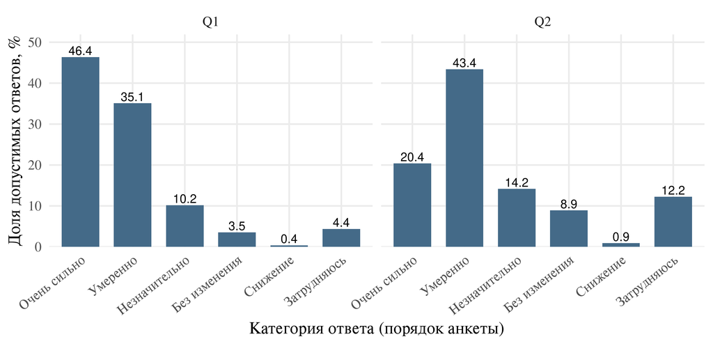

Рисунок 1. Q1/Q2: изменение цен за прошлый и следующий месяц, % ответов.

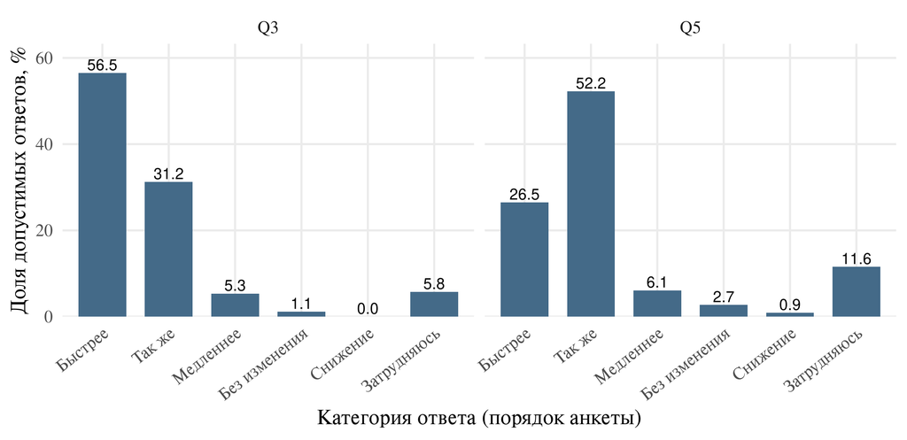

Рисунок 2. Q3/Q5: изменение цен за прошлый и следующий год, % ответов.

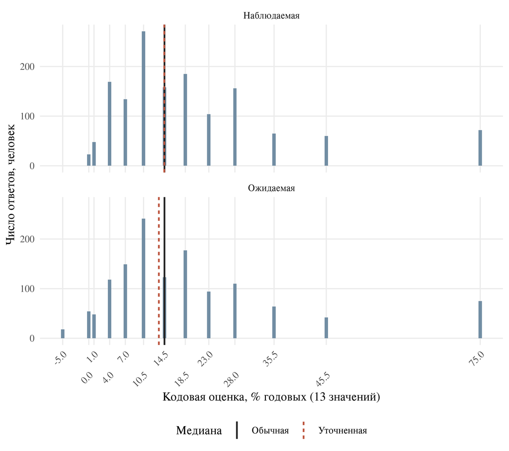

Рисунок 3. Частоты 13 кодов инфляции; обычные и уточненные медианы.

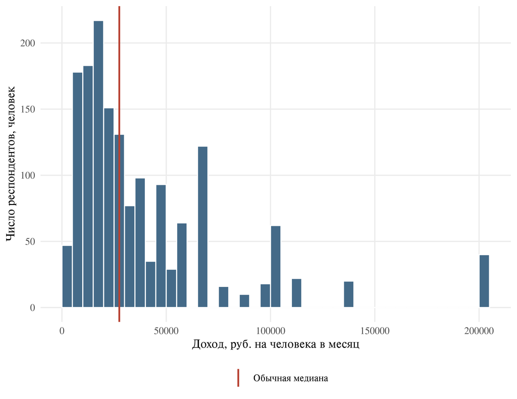

Рисунок 4. Среднедушевой доход: шаг 5000 руб.; линия — обычная медиана.

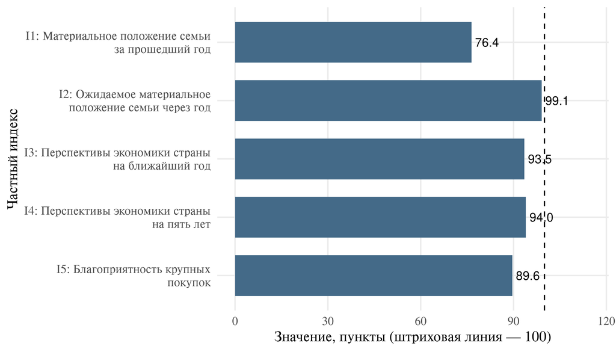

Рисунок 5. Частные индексы I1–I5, пункты; штриховая линия — 100.

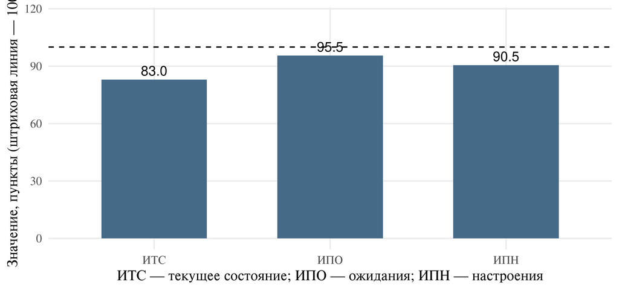

Рисунок 6. ИТС, ИПО и ИПН, пункты; штриховая линия — 100.

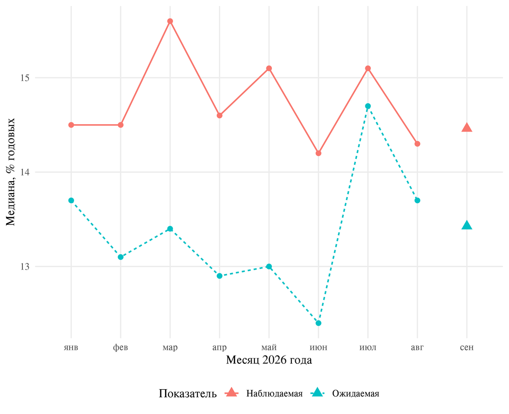

Рисунок 7. Инфляционные медианы: линии — опубликованный январь–август; треугольники — учебный сентябрь.

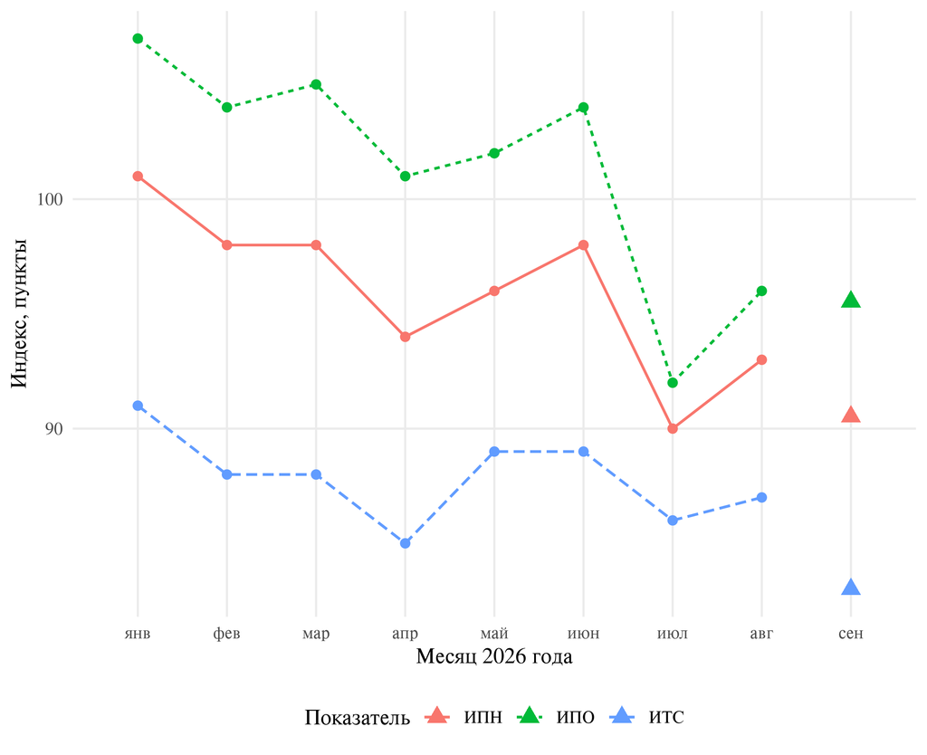

Рисунок 8. ИТС, ИПО, ИПН: линии — опубликованный январь–август; треугольники — учебный сентябрь.

# 8. Динамика и выводы

История — числовые подписи рис. 6 и 12 отчета инФОМ за август 2026, с. 10 и 14. Проверено 18.10.2026. Точность: медианы — 0,1 п. п., индексы — 1 пункт. В таблице «инФОМ» — опубликованный ряд, «Учебн.» — синтетическая выборка.

Таблица 30. Помесячные уровни и источник

| Месяц | Набл., % | Ожид., % | ИТС | ИПО | ИПН | Источник |
| --- | --- | --- | --- | --- | --- | --- |
| янв | 14.5 | 13.7 | 91 | 107.0 | 101.0 | инФОМ |
| фев | 14.5 | 13.1 | 88 | 104.0 | 98.0 | инФОМ |
| мар | 15.6 | 13.4 | 88 | 105.0 | 98.0 | инФОМ |
| апр | 14.6 | 12.9 | 85 | 101.0 | 94.0 | инФОМ |
| май | 15.1 | 13.0 | 89 | 102.0 | 96.0 | инФОМ |
| июн | 14.2 | 12.4 | 89 | 104.0 | 98.0 | инФОМ |
| июл | 15.1 | 14.7 | 86 | 92.0 | 90.0 | инФОМ |
| авг | 14.3 | 13.7 | 87 | 96.0 | 93.0 | инФОМ |
| сен | 14.5 | 13.4 | 83 | 95.5 | 90.5 | Учебн. |

Таблица 31. Август → учебный сентябрь: разность уровней

| Показатель | Август | Сентябрь | Разность | Единица |
| --- | --- | --- | --- | --- |
| Наблюдаемая медиана | 14.3 | 14.5 | 0.2 | п. п. |
| Ожидаемая медиана | 13.7 | 13.4 | -0.3 | п. п. |
| ИТС | 87.0 | 83.0 | -4.0 | пункты |
| ИПО | 96.0 | 95.5 | -0.5 | пункты |
| ИПН | 93.0 | 90.5 | -2.5 | пункты |

Наблюдаемая медиана — 14,5%, ожидаемая — 13,4%; обычные медианы — 14,5% и 14,5%. Различие уточненных оценок связано с интерполяцией внутри интервала.

ИТС = 83,0, ИПО = 95,5, ИПН = 90,5 пункта; все ниже 100. Изменения к августу: инфляционные медианы +0,2 и -0,3 п. п.; ИТС -4,0, ИПО -0,5, ИПН -2,5 пункта. Изменения ИТС и ИПО однонаправленны.

Доход рассчитан по 1613 анкетам; обычная медиана 27500,0 руб., уточненная 26164,1 руб. Пропуски исключались отдельно по каждому показателю; группировка влияет на уточненные оценки.

**Различия между опубликованным августом и синтетическим сентябрем нельзя трактовать как реальный сдвиг настроений населения или статистически установленное изменение.**

# Библиография

1. Методические указания к ЛР №1 «Обработка анкет и описательная статистика в R». НИЯУ МИФИ, 2026.
2. Индивидуальный файл Маркин.Никита.Алексеевич_Б24-902_Вар95.xlsx, вариант 95, 2000 анкет.
3. ООО «инФОМ». Измерение инфляционных ожиданий и потребительских настроений. Август 2026, волна 162. С. 10, 14, 20, 74–78. Предоставленный PDF, проверен 18.10.2026. https://www.cbr.ru/Collection/Collection/File/62282/inFOM_26-08.pdf.
4. Учебные материалы по R: ilovepdf_merged_merged.pdf.